# To What Extent Does Airbnb Review Intensity Lower Pricing Deviations via Comparable Listing Density?

# Introduction

Airbnb hosts set prices in a market where listings are differentiated by quality and location, and where information is imperfect for both guests (about quality) and hosts (about the “right” price). A large empirical literature employs hedonic pricing frameworks to demonstrate that Airbnb prices reflect size/quality, neighbourhood attractiveness, and spatial market structure, and that spatial dependence (where nearby listings’ prices move together) is crucial in accurately modeling price-setting (Gyódi & Nawaro, 2021; Boto-García et al., 2021). Furthermore, research on market concentration highlights that while city-level listing concentration often has no significant effect on prices, individual host listing shares (i.e., multi-listing power) allow hosts to exert greater influence over their pricing, even in otherwise competitive peer-to-peer markets (Bárcena-Martín, Benítez-Aurioles, & Pérez-Moreno, 2023).

Expanding on this, other work emphasizes reputation and reviews as informational mechanisms on platforms. Reviews and ratings can reduce information asymmetries, and evidence suggests that review-based measures (including sentiment/content) are meaningfully related to outcomes such as price. Additionally, some work models Airbnb prices as strategically interdependent across space (Lawani et al., 2019). Platform design can also shape equilibrium outcomes through reputation mechanisms: in a bilateral review environment, reciprocal behavior can influence ratings, which in turn affect prices (Proserpio, Xu, & Zervas, 2018).

Building on these insights, Lin and Yang (2024) provide a foundational examination of how customer reviews influence Airbnb pricing, using sentiment analysis and topic modeling to demonstrate that review content (particularly negative sentiments) has a significant and asymmetric impact on listing prices, with effects up to four times stronger for lower-priced listings. Their findings also reveal a lag effect in review impacts, suggesting that hosts adjust prices over time based on accumulated feedback, and that review influence diminishes with distance from city centers, implying spatial variations in market signals. This work highlights reviews as a dynamic tool for mitigating information asymmetries and refining pricing strategies in the short-term rental market.

Motivated by these ideas, particularly Lin and Yang's (2024) emphasis on reviews as a mechanism for iterative price adjustments, this project reframes pricing as a pricing-efficiency / learning question rather than only asking what predicts higher prices. If review intensity (e.g., reviews per month) reflects accumulated market feedback akin to the lagged review effects in Lin and Yang (2024), then more reviewed listings may price closer to the “going rate” for comparable listings. I therefore test whether review intensity is associated with lower pricing inefficiency (absolute deviation from the neighbourhood × room_type benchmark price), and whether the relationship is stronger in larger markets where there are more comparable listings and thus clearer price signals.

Data: The primary dataset is the NYC Airbnb listings dataset (unit of observation: individual listings), which contains listing prices, location identifiers (neighbourhood and borough), and review activity measures such as reviews_per_month. To account for broader safety differences across boroughs, I merge in 2019 NYPD complaint counts aggregated to the borough × law-category level and construct borough-level crime measures that are used as controls.

Research question: To what extent is review intensity (reviews_per_month) associated with lower pricing inefficiency (absolute deviation from the neighbourhood × room_type benchmark price), and is this relationship stronger in markets with clearer price signals (higher comparable listing density)?

To operationalize pricing efficiency, I construct an outcome measure of pricing inefficiency defined as the absolute deviation between a listing’s price and the typical price for similar listings in the same local market segment:

Variables (X, Y, Z):

Y (Outcome: pricing inefficiency). mispricing_abs = |price − median price within (neighbourhood, room_type)|. This measures how far a listing’s price deviates from the typical price of close comparables. The absolute value captures magnitude of inefficiency (over- or under-pricing), and the median benchmark is robust to outliers and extreme listings. Using (neighbourhood, room_type) defines a realistic comparable set based on the two most salient market segments on Airbnb.

X (Main explanatory: review intensity / feedback flow). reviews_per_month. Interpreted as the rate of incoming feedback/transactions: more review activity means more opportunities for a host to update beliefs about demand and willingness-to-pay, which should reduce persistent deviations from the local benchmark.

Z (Mechanism proxy: clarity of local price signals): Log_comp_density = log(1 + number of listings in the same (neighbourhood, room_type) cell) When there are more comparable listings, the local “going rate” is easier to infer and less noisy; if learning is the mechanism, the negative association between reviews_per_month and mispricing_abs should be stronger when log_comp_density is higher. Additional X variables: minimum_nights and availability_365: capture booking frictions and usage patterns that can mechanically relate to review flow and pricing behavior. number_of_reviews: captures accumulated reputation/tenure separately from the rate of new feedback. calculated_host_listings_count: proxies host scale/market power and professionalization, which may relate to both pricing strategies and review activity. borough-level crime measures (external merge): included to account for broad safety differences across boroughs that can shift baseline demand and prices; treated as a coarse location control (not a causal listing-level safety measure).

```python
#Setup cell
import pandas as pd
import numpy as np
import matplotlib.pyplot as plt
import sys
```

```python
df = pd.read_csv("../AB_NYC_2019.csv")
print(df.shape)
df.head()
df.info()
```

[output not shown]

# Data Cleaning/Loading

```python
# Make a working copy
df = df.copy()

# Ensure numeric price
df["price"] = pd.to_numeric(df["price"], errors="coerce")

# Drop rows missing key fields for definitions
df = df.dropna(subset=["price", "neighbourhood", "room_type"])

# Trim extreme values
df = df[df["price"].between(10, 1000)]

print(df.shape)
df[["price"]].describe()
```

```
(48645, 16)
```

|  | price |
| --- | --- |
| count | 48645.000000 |
| mean | 141.311789 |
| std | 116.731330 |
| min | 10.000000 |
| 25% | 69.000000 |
| 50% | 105.000000 |
| 75% | 175.000000 |
| max | 1000.000000 |

Create a Benchmark Price:

```python
bench = (
    df.groupby(["neighbourhood", "room_type"])["price"]
      .median()
      .rename("bench_price")
)

df = df.join(bench, on=["neighbourhood", "room_type"])
df["mispricing_abs"] = (df["price"] - df["bench_price"]).abs()

df[["price", "bench_price", "mispricing_abs"]].describe()
```

|  | price | bench_price | mispricing_abs |
| --- | --- | --- | --- |
| count | 48645.000000 | 48645.000000 | 48645.000000 |
| mean | 141.311789 | 119.564231 | 49.616035 |
| std | 116.731330 | 56.781329 | 84.425972 |
| min | 10.000000 | 13.000000 | 0.000000 |
| 25% | 69.000000 | 70.000000 | 10.000000 |
| 50% | 105.000000 | 110.000000 | 25.000000 |
| 75% | 175.000000 | 160.000000 | 53.000000 |
| max | 1000.000000 | 800.000000 | 951.000000 |

Create Z variable/mechanism:

```python
density = (
    df.groupby(["neighbourhood", "room_type"])
      .size()
      .rename("comp_density")
)

df = df.join(density, on=["neighbourhood", "room_type"])
df["log_comp_density"] = np.log1p(df["comp_density"])

df[["comp_density", "log_comp_density"]].describe()
```

|  | comp_density | log_comp_density |
| --- | --- | --- |
| count | 48645.000000 | 48645.000000 |
| mean | 776.764868 | 6.034207 |
| std | 662.646908 | 1.392124 |
| min | 1.000000 | 0.693147 |
| 25% | 187.000000 | 5.236442 |
| 50% | 583.000000 | 6.369901 |
| 75% | 1236.000000 | 7.120444 |
| max | 2030.000000 | 7.616284 |

**Merge in Crime**:

```python
crime = pd.read_csv("../crime_2019_boro_lawcat.csv")
crime.head()
crime.shape
```

```
(18, 3)
```

```python
crime_piv = (
    crime.pivot(index="boro_nm", columns="law_cat_cd", values="n")
         .reset_index()
)

crime_piv.columns.name = None

# rename to clearer variable names
crime_piv = crime_piv.rename(columns={
    "boro_nm": "neighbourhood_group",
    "FELONY": "crime_felony_2019",
    "MISDEMEANOR": "crime_misd_2019",
    "VIOLATION": "crime_viol_2019"
})

# map borough names to match airbnb neighbourhood_group
boro_map = {
    "MANHATTAN": "Manhattan",
    "BRONX": "Bronx",
    "BROOKLYN": "Brooklyn",
    "QUEENS": "Queens",
    "STATEN ISLAND": "Staten Island"
}
crime_piv["neighbourhood_group"] = crime_piv["neighbourhood_group"].map(boro_map)

crime_piv
```

|  | neighbourhood_group | crime_felony_2019 | crime_misd_2019 | crime_viol_2019 |
| --- | --- | --- | --- | --- |
| 0 | NaN | 5 | 1 | 1 |
| 1 | Bronx | 28236 | 55336 | 16992 |
| 2 | Brooklyn | 43971 | 67422 | 20710 |
| 3 | Manhattan | 36332 | 64344 | 15148 |
| 4 | Queens | 29118 | 47489 | 15463 |
| 5 | Staten Island | 4668 | 10149 | 4096 |

```python
df = df.merge(crime_piv, on="neighbourhood_group", how="left")

df[["crime_felony_2019","crime_misd_2019","crime_viol_2019"]].isna().mean()
df["crime_total_2019"] = df["crime_felony_2019"] + df["crime_misd_2019"] + df["crime_viol_2019"]
```

# Summary Statistics Tables

```python
from IPython.display import display

vars_main = [
    "mispricing_abs",
    "reviews_per_month",
    "log_comp_density",
    "minimum_nights",
    "availability_365",
    "number_of_reviews",
    "calculated_host_listings_count",
    "crime_total_2019",
]

df_summary = df[vars_main].dropna()

table1 = df_summary.describe().T[["count","mean","std","min","max"]]
table1 = table1.rename(columns={
    "count":"N",
    "mean":"Mean",
    "std":"St. Dev.",
    "min":"Min",
    "max":"Max"
})
table1 = table1.round(3)
table1["N"] = table1["N"].astype(int)

display(table1.style.set_caption("Table 1: Summary Statistics").format(precision=3))
```

Table 1: Summary Statistics

|  | N | Mean | St. Dev. | Min | Max |
| --- | --- | --- | --- | --- | --- |
| mispricing_abs | 38726 | 45.761 | 77.174 | 0.000 | 925.000 |
| reviews_per_month | 38726 | 1.375 | 1.682 | 0.010 | 58.500 |
| log_comp_density | 38726 | 6.035 | 1.392 | 0.693 | 7.616 |
| minimum_nights | 38726 | 5.845 | 17.286 | 1.000 | 1250.000 |
| availability_365 | 38726 | 114.601 | 129.399 | 0.000 | 365.000 |
| number_of_reviews | 38726 | 29.337 | 48.235 | 1.000 | 629.000 |
| calculated_host_listings_count | 38726 | 5.172 | 26.334 | 1.000 | 327.000 |
| crime_total_2019 | 38726 | 118790.520 | 15859.839 | 18913.000 | 132103.000 |

Table 1 reports summary statistics for the main variables used in the analysis. Most listings have low review intensity (reviews_per_month concentrated near zero), and the outcome variable (mispricing_abs) shows a strong right tail, indicating a small number of listings with very large deviations from the neighbourhood × room_type benchmark. Overall, this motivates using visualizations (and binning) to summarize patterns rather than relying on raw scatter alone.

```python
z = df_summary["log_comp_density"]
df_summary["Z_group"] = np.where(z <= z.median(), "Low Z", "High Z")

def make_table(sub_df):
    t = sub_df[vars_main].describe().T[["count", "mean", "std", "min", "max"]]
    t = t.rename(columns={
        "count": "N",
        "mean": "Mean",
        "std": "St. Dev.",
        "min": "Min",
        "max": "Max"
    })
    t["N"] = t["N"].astype(int)
    return t.round(3)


table2_low  = make_table(df_summary[df_summary["Z_group"] == "Low Z"])
table2_high = make_table(df_summary[df_summary["Z_group"] == "High Z"])

display(table2_low.style.set_caption("Table 2a: Summary Stats (Low Z)").format(precision=3))
display(table2_high.style.set_caption("Table 2b: Summary Stats (High Z)").format(precision=3))
```

Table 2a: Summary Stats (Low Z)

|  | N | Mean | St. Dev. | Min | Max |
| --- | --- | --- | --- | --- | --- |
| mispricing_abs | 19542 | 42.402 | 76.242 | 0.000 | 921.000 |
| reviews_per_month | 19542 | 1.484 | 1.809 | 0.010 | 58.500 |
| log_comp_density | 19542 | 4.961 | 1.165 | 0.693 | 6.370 |
| minimum_nights | 19542 | 5.387 | 16.915 | 1.000 | 1250.000 |
| availability_365 | 19542 | 125.781 | 132.670 | 0.000 | 365.000 |
| number_of_reviews | 19542 | 29.855 | 48.160 | 1.000 | 629.000 |
| calculated_host_listings_count | 19542 | 6.562 | 34.488 | 1.000 | 327.000 |
| crime_total_2019 | 19542 | 113496.553 | 19413.960 | 18913.000 | 132103.000 |

Table 2b: Summary Stats (High Z)

|  | N | Mean | St. Dev. | Min | Max |
| --- | --- | --- | --- | --- | --- |
| mispricing_abs | 19184 | 49.182 | 77.965 | 0.000 | 925.000 |
| reviews_per_month | 19184 | 1.264 | 1.533 | 0.010 | 14.000 |
| log_comp_density | 19184 | 7.129 | 0.399 | 6.433 | 7.616 |
| minimum_nights | 19184 | 6.312 | 17.643 | 1.000 | 999.000 |
| availability_365 | 19184 | 103.213 | 124.960 | 0.000 | 365.000 |
| number_of_reviews | 19184 | 28.809 | 48.308 | 1.000 | 607.000 |
| calculated_host_listings_count | 19184 | 3.755 | 13.580 | 1.000 | 327.000 |
| crime_total_2019 | 19184 | 124183.280 | 8136.744 | 115824.000 | 132103.000 |

Tables 2a–2b split the sample by the competition proxy (Z = log_comp_density), where “High Z” represents neighbourhood × room_type cells with more comparable listings (clearer local price signals). Comparing means across the two groups provides an initial check for whether mispricing levels and review intensity differ systematically across more vs less information-rich markets.

# Plots and Figures

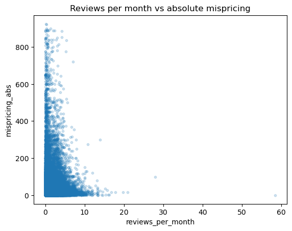

```python
import numpy as np
import matplotlib.pyplot as plt
tmp = df[["reviews_per_month","mispricing_abs"]].dropna().copy()

plt.scatter(tmp["reviews_per_month"], tmp["mispricing_abs"], alpha=0.2, s=10)
plt.title("Reviews per month vs absolute mispricing")
plt.xlabel("reviews_per_month")
plt.ylabel("mispricing_abs")
plt.show()
```

Figure 1: Reviews per month and absolute mispricing (listing-level). This scatter plot shows a strong right-skew in both variables: most listings have low review intensity and relatively low mispricing, with a long tail of high mispricing outliers. Visually, there is no clear linear trend across the full range, but the upper envelope of mispricing appears to shrink as reviews_per_month increases (very high mispricing is concentrated among low-review listings).

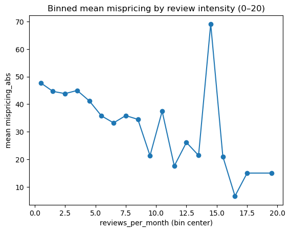

```python
tmp["rpm_bin"] = pd.cut(tmp["reviews_per_month"], bins=np.arange(0, 21, 1), right=False)
bin_means = tmp.groupby("rpm_bin", observed=True)["mispricing_abs"].mean()
x = [b.left + 0.5 for b in bin_means.index]

plt.plot(x, bin_means.values, marker="o")
plt.title("Binned mean mispricing by review intensity (0–20)")
plt.xlabel("reviews_per_month (bin center)")
plt.ylabel("mean mispricing_abs")
plt.show()
```

Figure 2 shows mean mispricing_abs by 1-unit bins of reviews_per_month (0–20). The binned trend generally declines as review intensity increases, which is consistent with a “learning/pricing-efficiency” interpretation (more review activity is associated with smaller deviations from the benchmark). Isolated spikes at higher bins likely reflect small cell sizes (few listings with very high reviews_per_month).

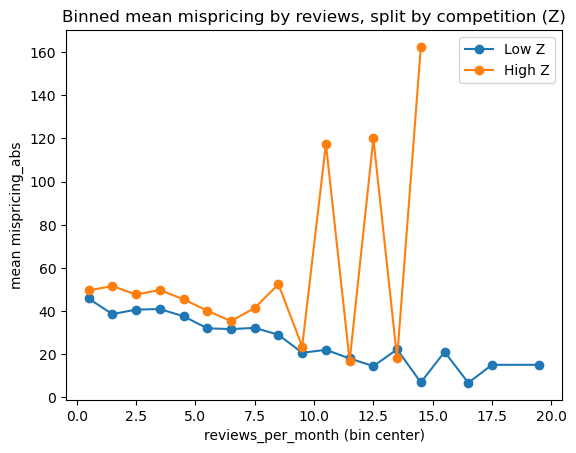

```python
tmp = df[["reviews_per_month","mispricing_abs","log_comp_density"]].dropna().copy()
tmp["Z_group"] = pd.qcut(tmp["log_comp_density"], 2, labels=["Low Z", "High Z"])

for g in ["Low Z", "High Z"]:
    sub = tmp[tmp["Z_group"] == g].copy()
    sub["rpm_bin"] = pd.cut(sub["reviews_per_month"], bins=np.arange(0, 21, 1), right=False)
    bin_means = sub.groupby("rpm_bin", observed=True)["mispricing_abs"].mean()
    x = [b.left + 0.5 for b in bin_means.index]
    plt.plot(x, bin_means.values, marker="o", label=g)

plt.title("Binned mean mispricing by reviews, split by competition (Z)")
plt.xlabel("reviews_per_month (bin center)")
plt.ylabel("mean mispricing_abs")
plt.legend()
plt.show()
```

Figure 3 repeats the binned means separately for Low Z vs High Z markets. The Low Z group shows a smoother decline in mean mispricing with review intensity, while the High Z series is noisier at higher bins, suggesting instability from small counts and/or more heterogeneous conditions in dense markets. This provides descriptive (not causal) evidence that the review–mispricing relationship may differ across market structure.

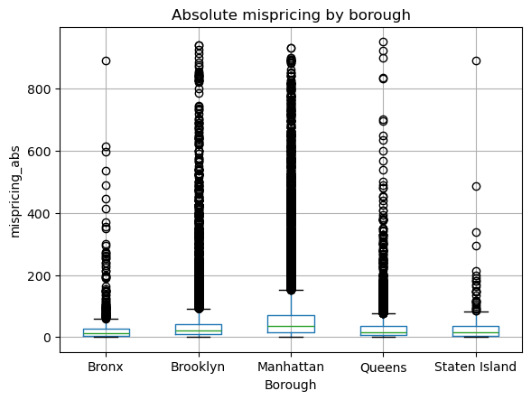

```python
df.boxplot(column="mispricing_abs", by="neighbourhood_group")
plt.title("Absolute mispricing by borough")
plt.suptitle("")
plt.xlabel("Borough")
plt.ylabel("mispricing_abs")
plt.show()
```

Figure 4 compares the distribution of mispricing_abs across boroughs. Medians differ by borough and all boroughs exhibit heavy upper tails, indicating that location-level factors matter for pricing deviations even after benchmarking within neighbourhood × room_type. This motivates including broad location controls (e.g., borough indicators and borough-level covariates such as crime).

# Conclusion

This first project in the broader project sequence establishes a descriptive baseline for the research question: To what extent is review intensity (reviews_per_month) associated with lower pricing inefficiency (mispricing_abs), and is that association stronger where local price signals are clearer (higher log_comp_density)?

Across the exploratory figures, the core pattern is consistent with the direction implied by the research question: higher review intensity is generally associated with lower absolute mispricing. The scatterplot shows that the largest mispricing values are concentrated among listings with very low reviews_per_month, while the binned-mean plot over 0–20 reviews/month trends downward overall (with visible noise in higher-review bins that are likely based on far fewer observations). This supports the idea that more frequent review activity, interpreted as ongoing feedback, corresponds to prices being closer to the neighbourhood × room_type benchmark.

These findings are intentionally descriptive rather than causal and are meant to motivate the next stages of the project. In later submissions, the goal will be to quantify to what extent review intensity is associated with mispricing, for example by estimating magnitudes, assessing whether the interaction with log_comp_density is statistically meaningful, and testing robustness using additional controls and regression-based analysis.

# References

Bárcena-Martín, E., Benítez-Aurioles, B., & Pérez-Moreno, S. (2023). Peer-to-peer accommodation prices: City listing concentration and host listing share. *Tourism Economics, 29*(6), 1499–1519. https://doi.org/10.1177/13548166221110526

Boto-García, D., Mayor, M., & De la Vega, P. (2021). Spatial price mimicking on Airbnb: Multi-host vs single-host. *Tourism Management, 87*, Article 104365. https://doi.org/10.1016/j.tourman.2021.104365

Gyódi, K., & Nawaro, Ł. (2021). Determinants of Airbnb prices in European cities: A spatial econometrics approach. *Tourism Management, 86*, Article 104319. https://doi.org/10.1016/j.tourman.2021.104319

Lawani, A., Reed, M. R., Mark, T., & Zheng, Y. (2019). Reviews and price on online platforms: Evidence from sentiment analysis of Airbnb reviews in Boston. *Regional Science and Urban Economics, 75*, 22–34. https://doi.org/10.1016/j.regsciurbeco.2018.11.003

Lin, W., & Yang, F. (2024). The price of short-term housing: A study of Airbnb on 26 regions in the United States. *Journal of Housing Economics, 65*, Article 102005. https://doi.org/10.1016/j.jhe.2024.102005

Proserpio, D., Xu, W., & Zervas, G. (2018). You get what you give: Theory and evidence of reciprocity in the sharing economy. *Quantitative Marketing and Economics, 16*(4), 371–407. https://doi.org/10.1007/s11129-018-9201-9

dgomonov. (2019). New York City Airbnb Open Data [Data set]. Kaggle. Retrieved January 23, 2026, from https://www.kaggle.com/datasets/dgomonov/new-york-city-airbnb-open-data

New York City Police Department. (n.d.). NYPD Complaint Data Historic [Data set]. NYC Open Data (via data.gov). Retrieved January 30, 2026, from https://catalog.data.gov/dataset/nypd-complaint-data-historic